# Vignette_1_simulated_data

### Autocorrelation plots

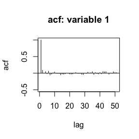

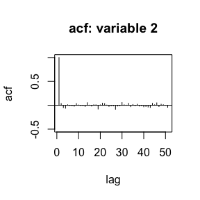

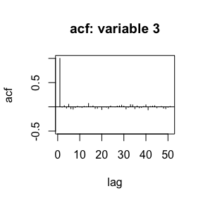

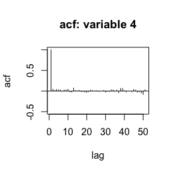

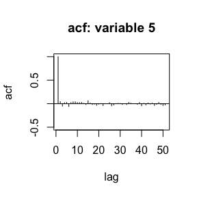

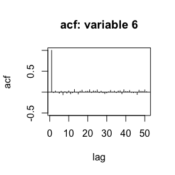

```r
title = paste("acf: variable", 1:p)
acf.calc(sim.res$simulated.mu, title = title)
```

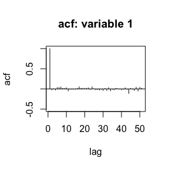

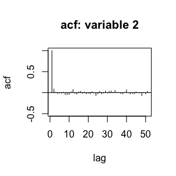

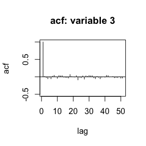

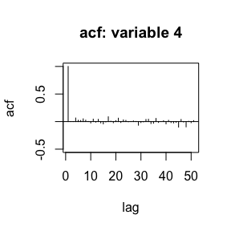

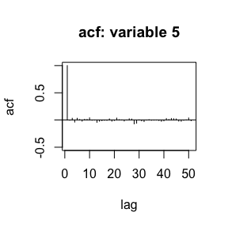

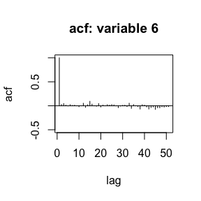

```r
acf.calc(sim.res$simulated.sig, title = title)
```

From the convergence plots and the autocorrelation plots, we see that the posterior distributions of both the mean and variance seem to converge to equilibrium in first few iterations.

### Marginal plot

We draw and compare the marginal density plots using the full data, the CC data and the imputed data from the last iteration of MCMC using the **mvnimpute** package.

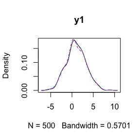

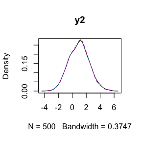

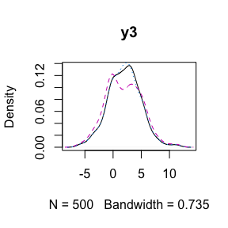

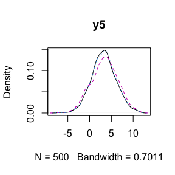

```r
for (i in c(1, 2, 3, 5)) {
  plot(density(full[, i]), main = colnames(full)[i])
  lines(density(observed[!is.na(observed[, i]), i]), col = 6, lty = 2)
  lines(density(sim.res$imputed.data[[iter]][, i]), col = 4, lty = 3)
}
```

The black line is the density plot of the full data, the blue dotted line is the imputed data using the **mvnimpute** pacakge, the pink dashed line is the CC data. We see that the imputed data density align with the full data density quite well.

### Linear Regression

```r
full.reg <- coef(lm(y4 ~ y1 + y2 + y3 + y5 + y6, data = data.frame(full)))
cc.reg <- coef(lm(y4 ~ y1 + y2 + y3 + y5 + y6, data = data.frame(observed)))

### imputed data
gibbs <- seq(800, 1000, 50)

#### mvnimpute
mvnimpute.dat <- list()
model.param <- list()
for (i in 1:length(gibbs)) {

  mvnimpute.dat[[i]] <- sim.res$imputed.data[[gibbs[i]]]
  colnames(mvnimpute.dat[[i]]) <- paste0("y", 1:p)
  model.param[[i]] <- lm(y4 ~ y1 + y2 + y3 + y5 + y6, data.frame(mvnimpute.dat[[i]]))

}

mvnimpute.mod <- summary(mice::pool(model.param))
sim.reg <- mvnimpute.mod[, 2]

reg.compare <- data.frame(
  true = true.beta,
  full = full.reg,
  mvnimpute = sim.reg,
  cc = cc.reg
)
reg.compare
```

```
#>                   true        full   mvnimpute           cc
#> (Intercept) 3.73975211  4.07379080  4.06506771  4.215508888
#> y1          0.03742948  0.02917612  0.02735768 -0.004483437
#> y2          0.02449541  0.09440116  0.10648160  0.069068147
#> y3          0.01128354  0.01674152  0.01285773  0.017741180
#> y5          0.01602758  0.05832823  0.05773384  0.055510475
#> y6          0.02553464 -0.05083920 -0.04895012 -0.035768977
```

```r
options(old)
```